[OHI Science](http://ohi-science.org) | [Citation policy](http://ohi-science.org/citation-policy/)

# OHI 2017 - Food Provision: Preparing RAM B/Bmsy data

Compiled on Mon Nov 13 13:24:27 2017 by frazier

# Summary

This script prepares the RAM B/Bmsy data: 1. Relevant data are collected from the RAM database 2. Missing years are gapfilled when appropriate 3. RAM and SAUP species names are harmonized in a few cases 4. RAM stocks are associated with the corresponding OHI and FAO regions

## Updates from previous assessment

Data describing the spatial boundaries of the RAM stocks were not previously available. We meant to gapfill RAM B/Bmsy values last year, but due to an oversight we did not use gapfilled data.

# Data

## B/Bmsy values from stock assessments

Reference: RAM Legacy Stock Assessment Database v3.8. 2017. Shared with us by folks at UW. http://ramlegacy.org.

- Description: B/Bmsy value by stock and year (other data, which we do not use, are also available in the database)
- Native data resolution: stock (fish stock, species and region specific)
- Time range: 1950 - 2014
- Format: R data files (.rds)

## Stock range data

Reference: Christopher M. Free. 2017. Mapping fish stock boundaries for the original Ram Myers stock-recruit database. https://marine.rutgers.edu/~cfree/mapping-fish-stock-boundaries-for-the-original-ram-myers-stock-recruit-database/. downloaded 9/25/2017.

- Downloaded: 9/25/2017
- Description: Shapefiles for each stock describing their distribution
- Native data resolution: Spatial shapefiles
- Format: Shapefiles

## Setup

```r
knitr::opts_chunk$set(fig.width = 6, fig.height = 4, fig.path = 'figs/',message = FALSE, warning = FALSE)

## highlight out when knitting
# setwd("globalprep/fis/v2017")

## Libraries
library(dplyr)
library(tidyr)
library(readr)
library(sf)
library(ggplot2)

source('../../../src/R/common.R')

## Paths for data
path_raw_data = file.path(dir_M, "git-annex/globalprep/_raw_data/SAUP/d2017")
```

## Obtain RAM B/Bmsy data

The data is stored as a relational database in an R object. The following tables are included:

1. timeseries  
   The time series data is a matrix object with the following headers/columns:
1. assessid (2) stockid (3) stocklong (4) tsid (5) tsyear (6) tsvalue
2. bioparams  
   The time series data is a matrix object with the following headers/columns:
1. assessid (2) stockid (3) stocklong (4) bioid (5) biovalue (6) bioyear (7) bionotes
3. timeseries.views.data  
   This stores the timeseries values with timeseries type along the columns (TB, SSB, TN, R, TC, TL, F, ER, TB/TBmsy, SSB/SSBmsy, F/Fmsy, ER/ERmsy, Btouse, Ctouse, Utouse, B/Bmsytouse, U/Umsytouse, TB/TBmgt, SSB/SSBmgt, F/Fmgt, ER/ERmgt, B/Bmgttouse, U/Umgttouse) and stocks along the rows
4. timeseries.views.units  
   This stores the timeseries units (or time series source for touse time series), with timeseries type along the columns (TB, SSB, TN, R, TC, TL, F, ER) and stocks along the rows
5. timeseries.views.ids  
   This stores the timeseries ids with timeseries id along the columns (TB, SSB, TN, R, TC, TL, F, ER, TB/TBmsy, SSB/SSBmsy, F/Fmsy, ER/ERmsy, Btouse, Ctouse, Utouse, B/Bmsytouse, U/Umsytouse, TB/TBmgt, SSB/SSBmgt, F/Fmgt, ER/ERmgt, B/Bmgttouse, U/Umgttouse) and stocks along the rows
6. bioparams.views.data  
   This stores the bioparams values, with bioparam type along the columns (TBmsy, SSBmsy, Nmsy, MSY, Fmsy, ERmsy, TB0, SSB0, M, Bmsytouse, Umsytouse, TBmgt, SSBmgt, Fmgt, ERmgt, Bmgttouse, Umgttouse) and stocks along the rows
7. bioparams.views.units  
   This stores the bioparams units (or parameter source for touse parameters), with bioparam type along the columns (TBmsy, SSBmsy, Nmsy, MSY, Fmsy, ERmsy, TB0, SSB0, M, TBmgt, SSBmgt, Fmgt, ERmgt) and stocks along the rows
8. bioparams.views.ids  
   This stores the bioparams ids, with bioparam id along the columns (TBmsy, SSBmsy, Nmsy, MSY, Fmsy, ERmsy, TB0, SSB0, M, Bmsytouse, Umsytouse, TBmgt, SSBmgt, Fmgt, ERmgt, Bmgttouse, Umgttouse) and stocks along the rows
9. meta.data  
   This stores assorted metadata associated with the stock, with datatypes along the columns (assessid, stockid, stocklong, scientificname, FisheryType, region, areaid, areaname, assessorid, mgmt, management authority) and stock by row

```r
load(file.path(dir_M, "git-annex/globalprep/_raw_data/RAM/d2017/RAM v3.80/DB Files With Assessment Data/DBdata.RData"))

ram_bmsy <- data.frame(timeseries) %>%
  dplyr::filter(tsid == "BdivBmsytouse-dimensionless") %>%
  dplyr::filter(!is.na(tsvalue)) %>%
  dplyr::mutate(tsyear = as.numeric(as.character(tsyear))) %>%
  dplyr::filter(tsyear > 1979) %>%
  dplyr::select(assessid, year=tsyear, ram_bmsy = tsvalue)
```

## Gapfill RAM data when there are missing years

A few of the predicted B/Bmsy values go below zero. We convert anything with a RAM B/Bmsy value < 0.015 to 0.015, which is the minimum observed B/Bmsy value in the data.

```r
## gapfill ram_bmsy
ram_gf_check <- ram_bmsy %>%
  filter(year >= 2001) %>%
  spread(year, ram_bmsy)
## based on this it seams reasonable to gap-fill missing values

ram_bmsy_gf <- ram_bmsy %>%
  filter(year >= 2001 & year <= 2014) %>%   # 2014 corresponds to the final year of SAUP catch data
  group_by(assessid) %>%
  mutate(years_data = length(ram_bmsy[year >= 2004])) %>%
  ungroup() %>%
  filter(years_data >= 4) %>%
  spread(year, ram_bmsy) %>%
  gather("year", "ram_bmsy", -assessid, -years_data) %>%
  mutate(year = as.numeric(year)) %>%
  mutate(ram_bmsy = as.numeric(ram_bmsy)) %>%
  mutate(gapfilled = NA) %>%
  mutate(gapfilled = ifelse(years_data == 11, gapfilled, paste(11 - years_data, "years gf", sep = " ")))

tmp <- ram_bmsy_gf %>%
  dplyr::select(assessid, gapfilled) %>%
  unique()
length(tmp$gapfilled)   # 225 stocks with at least 5 years of data in past 11 years
```

```
## [1] 225
```

```r
table(tmp$gapfilled)
```

```
##
## 1 years gf 2 years gf 3 years gf 4 years gf 5 years gf 6 years gf
##         16         34         41         32         22         14
## 7 years gf
##         32
```

```r
sum(table(tmp$gapfilled))  # 191 stocks have at least one year of B/Bmsy values gapfilled
```

```
## [1] 191
```

```r
# regression model for prediction for each stock
ram_bmsy_gf <- ram_bmsy_gf %>%
  group_by(assessid) %>%
  do({
    mod <- lm(ram_bmsy ~ year, data=.)
    ram_bmsy_predict <- predict(mod, newdata=.[c('year')])
    data.frame(., ram_bmsy_predict)
  }) %>%
  ungroup()

# a few of the predicted B/Bmsy values go below zero.  We convert anything with a RAM BBmsy value < 0.015 to 0.015
# which is the minimum observed B/Bmsy value in the data

ram_bmsy_gf <- ram_bmsy_gf %>%
  mutate(ram_bmsy_predict = ifelse(ram_bmsy_predict < 0.015, 0.015, ram_bmsy_predict)) %>%
  mutate(method = ifelse(is.na(ram_bmsy), paste0("lm, ", gapfilled), NA)) %>%
  mutate(gapfilled = ifelse(is.na(ram_bmsy), "1", "0")) %>%
  mutate(ram_bmsy = ifelse(is.na(ram_bmsy), ram_bmsy_predict, ram_bmsy)) %>%
  dplyr::select(assessid, year, ram_bmsy, gapfilled, method)

write.csv(ram_bmsy_gf, "int/ram_stock_bmsy_gf.csv", row.names=FALSE)
```

The following code can be used to estimate the amount of error for each year due to gapfilling. In the first example, the gapfilling model is estimated using all the data prior to 2014. The model is then used to estimate the 2014 data and examine how accurate the estimates are. In this case, we assume all years of data prior to 2014 is available (i.e., only one missing year of data), which often isn’t the case becasue stocks are often missing multiple years of data. The second example examines the error in the 2014 data if the B/Bmsy data only go to 2009 (i.e., 5 missing years of data).

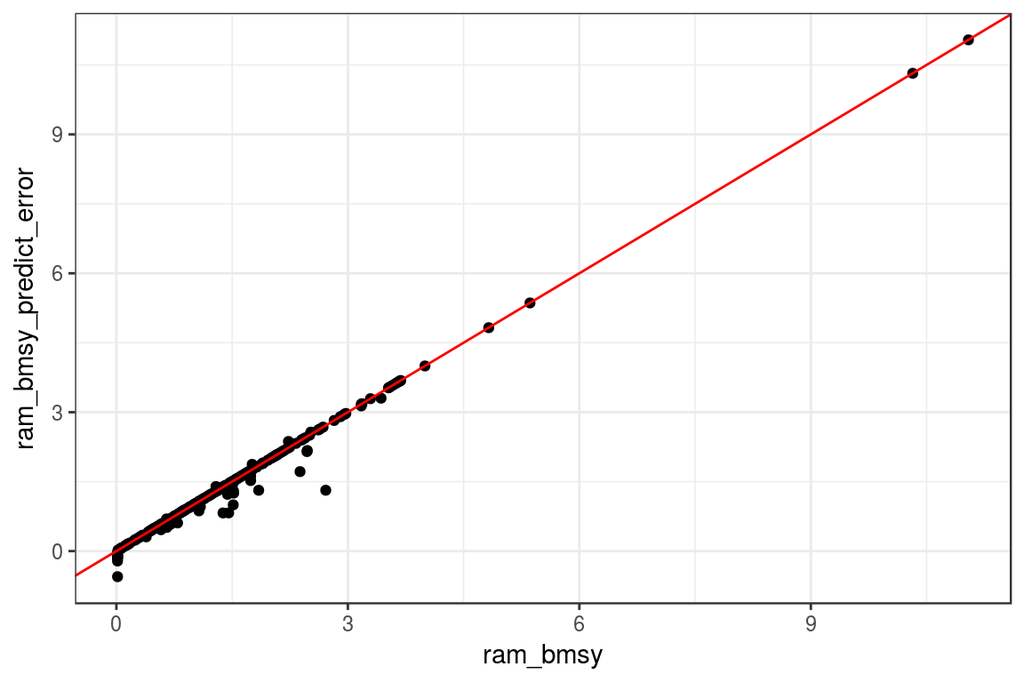

```r
# Example 1
ram_bmsy_gf_check1 <- ram_bmsy_gf %>%
  group_by(assessid) %>%
  do({
    mod <- lm(ram_bmsy ~ year, data= filter(., year < 2014))  ### change year to test different accuracy levels based on # years of data used in lm
    ram_bmsy_predict_error <- predict(mod, newdata=.[c('year')])
    data.frame(., ram_bmsy_predict_error)
  })

ggplot(data = filter(ram_bmsy_gf_check1, year==2014), aes(y=ram_bmsy_predict_error, x=ram_bmsy)) +
  geom_point() +
  theme_bw() +
  geom_abline(slope=1, intercept=0, color="red")
```

```r
summary(lm(ram_bmsy_predict_error ~ ram_bmsy, data=filter(ram_bmsy_gf_check1, year==2014)))
```

```
##
## Call:
## lm(formula = ram_bmsy_predict_error ~ ram_bmsy, data = filter(ram_bmsy_gf_check1,
##     year == 2014))
##
## Residuals:
##      Min       1Q   Median       3Q      Max
## -1.35929  0.03688  0.03763  0.03828  0.17683
##
## Coefficients:
##              Estimate Std. Error t value Pr(>|t|)
## (Intercept) -0.036541   0.014180  -2.577   0.0106 *
## ram_bmsy     0.999007   0.007308 136.709   <2e-16 ***
## ---
## Signif. codes:  0 '***' 0.001 '**' 0.01 '*' 0.05 '.' 0.1 ' ' 1
##
## Residual standard error: 0.1414 on 223 degrees of freedom
## Multiple R-squared:  0.9882, Adjusted R-squared:  0.9882
## F-statistic: 1.869e+04 on 1 and 223 DF,  p-value: < 2.2e-16
```

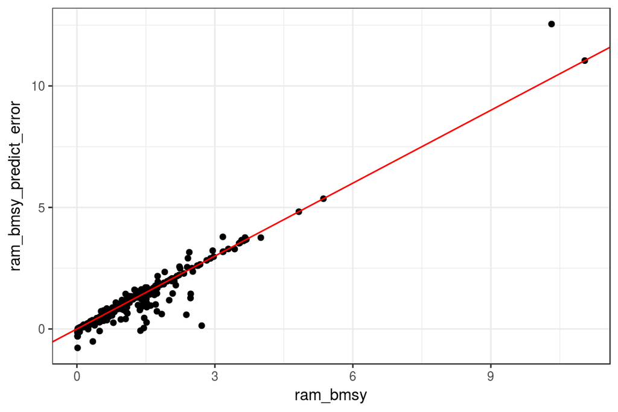

```r
# Example 2
ram_bmsy_gf_check2 <- ram_bmsy_gf %>%
  group_by(assessid) %>%
  do({
    mod <- lm(ram_bmsy ~ year, data= filter(., year < 2010))  ### change year to test different accuracy levels based on # years of data used in lm
    ram_bmsy_predict_error <- predict(mod, newdata=.[c('year')])
    data.frame(., ram_bmsy_predict_error)
  })

ggplot(data = filter(ram_bmsy_gf_check2, year==2014), aes(y=ram_bmsy_predict_error, x=ram_bmsy)) +
  geom_point() +
  theme_bw() +
  geom_abline(slope=1, intercept=0, color="red")
```

```r
summary(lm(ram_bmsy_predict_error ~ ram_bmsy, data=filter(ram_bmsy_gf_check2, year==2014)))
```

```
##
## Call:
## lm(formula = ram_bmsy_predict_error ~ ram_bmsy, data = filter(ram_bmsy_gf_check2,
##     year == 2014))
##
## Residuals:
##      Min       1Q   Median       3Q      Max
## -2.54892 -0.02386  0.08135  0.15231  1.83672
##
## Coefficients:
##             Estimate Std. Error t value Pr(>|t|)
## (Intercept) -0.17685    0.03924  -4.507 1.06e-05 ***
## ram_bmsy     1.05502    0.02022  52.177  < 2e-16 ***
## ---
## Signif. codes:  0 '***' 0.001 '**' 0.01 '*' 0.05 '.' 0.1 ' ' 1
##
## Residual standard error: 0.3914 on 223 degrees of freedom
## Multiple R-squared:  0.9243, Adjusted R-squared:  0.9239
## F-statistic:  2722 on 1 and 223 DF,  p-value: < 2.2e-16
```

## Standardize species names

In most cases, the RAM and SAUP data use the same species names, but there are a few exceptions. The following code identifies species in the RAM data that are not in the SAUP data. In these cases, different species names may be used (although not necessarily because some of the species may be present in RAM, but not SAUP, for other reasons). For these species, I used fishbase to explore synonyms and create a table to harmonize the RAM species names with the SAUP species names (saved as: int/RAM_species_to_SAUP.csv).

```r
# get list of RAM species
ram_sp <- ram_bmsy_gf %>%
  left_join(data.frame(meta.data), by = "assessid") %>%
  dplyr::select(scientificname) %>%
  unique() %>%
  arrange(scientificname)

# SAUP species
saup_sp <- read_csv(file.path(dir_M,'git-annex/globalprep/fis/v2017/int/stock_catch_by_rgn.csv')) %>%
  dplyr::rename(saup_scientificname = taxon_scientific_name) %>%
  dplyr::select(saup_scientificname) %>%
  unique() %>%
  arrange(saup_scientificname)


# compare names
 tmp <- sort(setdiff(ram_sp$scientificname, saup_sp$saup_scientificname))
 write.csv(tmp, "int/unmatched_RAM_species.csv", row.names=FALSE)

# Then I hand-looked up each of the missing ones to generate this list
 ram_name_corr <- read.csv("int/RAM_species_to_SAUP.csv", stringsAsFactors = FALSE) %>%
   filter(!is.na(SAUP_species))  # SAUP to RAM name conversion

  ram_name_corr
```

```
##                 RAM_species              SAUP_species
## 1       Chrysophrys auratus            Pagrus auratus
## 2 Epinephelus flavolimbatus Hyporthodus flavolimbatus
## 3      Epinephelus niveatus      Hyporthodus niveatus
## 4            Loligo pealeii       Doryteuthis pealeii
## 5          Loligo reynaudii     Doryteuthis reynaudii
## 6      Merluccius paradoxus       Merluccius capensis
## 7      Reinhardtius stomias       Atheresthes stomias
## 8          Squalus suckleyi         Squalus acanthias
## 9       Tetrapturus albidus            Kajikia albida
```

## Identify FAO and OHI regions for RAM stocks

Here we identify the FAO/OHI regions where each RAM stock is located. This involved the following steps:

1. Create a intersection map that identifies each FAO/OHI region.
2. Overlay each of the RAM stocks on the region map to determine where they fall. There were 2 general challenges to doing this. A few of the stocks did not have a complete dataframe in the shapefile and could not be joined to the other data. A few stocks had intersecting polygons and consequently would not run. In the first case, I added these data by hand later in the process. For the second case, I fixed the intersections and added later.

```r
RAM_spatial_dir <- file.path(dir_M, "git-annex/globalprep/_raw_data/RAM/d2017/ramldb_boundaries/ramldb_boundaries")

ram_sf <- list.files(RAM_spatial_dir, pattern = "shp")

ram_sf <- gsub(".shp", "", ram_sf)

setdiff(ram_sf, ram_bmsy_gf$assessid) ## stocks with variables other than b/bmsy
setdiff(ram_bmsy_gf$assessid, ram_sf) ## oh goody!  all the b/bmsy stocks have corresponding maps!  Awesome!
ram_sf <- intersect(ram_bmsy_gf$assessid, ram_sf) # get these spatial data

# get rid of some weird ones with issues (will add by hand at end)
# missing dataframe
ram_sf <- ram_sf[-which(ram_sf == "SEFSC-BLACKGROUPERGMSATL-1986-2008-THORSON")]
ram_sf <- ram_sf[-which(ram_sf == "SEFSC-BSBASSSATL-1950-2010-HIVELY")]
ram_sf <- ram_sf[-which(ram_sf == "SEFSC-RGROUPSATL-1976-2009-HIVELY")]
ram_sf <- ram_sf[-which(ram_sf == "SEFSC-RPORGYSATLC-1972-2012-HIVELY")]
ram_sf <- ram_sf[-which(ram_sf == "SEFSC-RSNAPSATLC-1954-2010-HIVELY")]
ram_sf <- ram_sf[-which(ram_sf == "SEFSC-SNOWGROUPSATLC-1974-2013-HIVELY")]
ram_sf <- ram_sf[-which(ram_sf == "SEFSC-TILESATLC-1961-2011-HIVELY")]
ram_sf <- ram_sf[-which(ram_sf == "SEFSC-VSNAPSATLC-1945-2012-HIVELY")]


#self_intersection
ram_sf <- ram_sf[-which(ram_sf == "AFSC-GHALBSAI-1960-2015-HIVELY")]
ram_sf <- ram_sf[-which(ram_sf == "NEFSC-HAD5Y-1964-2011-CHING")]
ram_sf <- ram_sf[-which(ram_sf == "AFSC-SABLEFEBSAIGA-1958-2010-STACHURA")]
ram_sf <- ram_sf[-which(ram_sf == "NEFSC-SCALL5ZMAB-1964-2013-HIVELY")]
ram_sf <- ram_sf[-which(ram_sf == "NEFSC-WITFLOUN5Y-1982-2008-WIGLEY")]


## get a sample file to convert other spatial data
tmp <- read_sf(dsn = RAM_spatial_dir, layer = ram_sf[1])


##################################
## Combine OHI and FAO regions
## get OHI regions and transform

ohi <- read_sf(dsn = file.path(dir_M, "git-annex/globalprep/spatial/v2017"), layer = "regions_2017_update")
ohi <- st_transform(ohi, st_crs(tmp)$epsg)

# ohi <- as(ohi, "Spatial") # convert to spatial polygons file


## FAO region

fao_regions <- read_sf(dsn = file.path(dir_M, "git-annex/Global/NCEAS-Regions_v2014/orig/FAO_AREAS"), layer="FAO_AREAS") %>%
  filter(F_LEVEL == "MAJOR")

fao_ohi <- st_intersection(ohi, fao_regions)

st_write(fao_ohi, dsn = file.path(dir_M, "git-annex/globalprep/fis/v2017/int"),
                             layer = "ohi_fao_rgns", driver = "ESRI Shapefile")


############################################
## Overlay stock data on fao-ohi region data

fao_ohi <- st_read(file.path(dir_M, "git-annex/globalprep/fis/v2017/int"),
        layer = "ohi_fao_rgns")

stock_fao_ohi <- NA
for(stock in ram_sf) {   # stock = ram_sf[85]
    cat(paste0(stock, "\n"))
    tmp_poly <- read_sf(dsn = RAM_spatial_dir, layer = stock)
    tmp_fao_ohi <- st_intersection(fao_ohi, tmp_poly)
    if(sum(is.na(stock_fao_ohi))==1){
      stock_fao_ohi <- tmp_fao_ohi
    }else
    {stock_fao_ohi <- rbind(stock_fao_ohi, tmp_fao_ohi)}
}

## Add in stocks that didn't work

## Fix self intersections and add
intersects <- c("AFSC-GHALBSAI-1960-2015-HIVELY",
                "NEFSC-HAD5Y-1964-2011-CHING",
                "AFSC-SABLEFEBSAIGA-1958-2010-STACHURA",
                "NEFSC-SCALL5ZMAB-1964-2013-HIVELY",
                "NEFSC-WITFLOUN5Y-1982-2008-WIGLEY")

stock_fao_ohi_intersects <- NA
for(stock in intersects) {   # stock = intersects[3]
  cat(paste0(stock, "\n"))
  tmp_poly <- read_sf(dsn = RAM_spatial_dir, layer = stock)
  tmp_poly <- st_buffer(tmp_poly, 0.0)
  tmp_fao_ohi_intersects <- st_intersection(fao_ohi, tmp_poly)
  if(sum(is.na(stock_fao_ohi_intersects))==1){
    stock_fao_ohi_intersects <- tmp_fao_ohi_intersects
  }else
  {stock_fao_ohi_intersects <- rbind(stock_fao_ohi_intersects, tmp_fao_ohi_intersects)}
}

stock_fao_ohi_v2 <- rbind(stock_fao_ohi, stock_fao_ohi_intersects) #5940


## clean data
# include only features with area:
stock_fao_ohi_shps <- stock_fao_ohi_v2[st_dimension(stock_fao_ohi_v2) == 2,] #5904

stock_fao_ohi_shps <- stock_fao_ohi_shps[!is.na(st_dimension(stock_fao_ohi_shps)), ] #5904

## Fix GEOMETRYCOLLECTION features, http://r-spatial.org/r/2017/03/19/invalid.html

type <- st_is(stock_fao_ohi_shps, "GEOMETRYCOLLECTION")

stock_fao_ohi_shps[type, ] <- st_buffer(stock_fao_ohi_shps[type, ], 0.0)

#check:
type <- st_is(stock_fao_ohi_shps, "GEOMETRYCOLLECTION")


## Get areas in case we want to later weight the data
stock_fao_ohi_shps$RAM_area_m2 <- st_area(stock_fao_ohi_shps)

## save spatial file (if concerned about next step, which converts to a csv and loses spatial information):
# st_write(stock_fao_ohi_shps, dsn = file.path(dir_M, "git-annex/globalprep/fis/v2017/int/RAM"),
#         layer = "RAM_fao_ohi_no_incompletes", driver = "ESRI Shapefile")



## rbindfill these data (missing a lot of the columns for some reason)

incompletes <- c("SEFSC-BLACKGROUPERGMSATL-1986-2008-THORSON",
                "SEFSC-BSBASSSATL-1950-2010-HIVELY",
                "SEFSC-RGROUPSATL-1976-2009-HIVELY",
                "SEFSC-RPORGYSATLC-1972-2012-HIVELY",
                "SEFSC-RSNAPSATLC-1954-2010-HIVELY",
                "SEFSC-SNOWGROUPSATLC-1974-2013-HIVELY",
                "SEFSC-TILESATLC-1961-2011-HIVELY",
                "SEFSC-VSNAPSATLC-1945-2012-HIVELY")

stock_fao_ohi_incompletes <- NA
for(stock in incompletes) {   # stock = incompletes[3]
  cat(paste0(stock, "\n"))
  tmp_poly <- read_sf(dsn = RAM_spatial_dir, layer = stock)
  tmp_fao_ohi_incompletes <- st_intersection(fao_ohi, tmp_poly)
  tmp_fao_ohi_incompletes$assessid <- stock
  if(sum(is.na(stock_fao_ohi_incompletes))==1){
    stock_fao_ohi_incompletes <- tmp_fao_ohi_incompletes
  }else
  {stock_fao_ohi_incompletes <- rbind(stock_fao_ohi_incompletes, tmp_fao_ohi_incompletes)}
}

stock_fao_ohi_incompletes$RAM_area_m2 <- st_area(stock_fao_ohi_incompletes)

stock_fao_ohi_all <- plyr::rbind.fill(stock_fao_ohi_shps, stock_fao_ohi_incompletes) %>%
  dplyr::select(type_w_ant, rgn_ant_id, F_CODE, assessid, RAM_area_m2) %>%
  group_by(rgn_ant_id, F_CODE, assessid) %>%
  summarize(RAM_area_m2 = sum(RAM_area_m2)) %>%
  rename(rgn_id = rgn_ant_id, fao_id = F_CODE)

write.csv(stock_fao_ohi_all, "int/RAM_fao_ohi_rgns.csv", row.names=FALSE)
```

## Combine all the data

Final formatting of the data is performed.

```r
ram_spatial <- read.csv("int/RAM_fao_ohi_rgns.csv", stringsAsFactors = FALSE)

ram_meta <- data.frame(meta.data) %>%
  dplyr::select(assessid, stockid, scientificname)

setdiff(ram_spatial$assessid, ram_meta$assessid) # make sure all the spatial data has corresponding metadata (should be 0)
```

```
## character(0)
```

```r
# join with metadata
ram_spatial <- ram_spatial %>%
  left_join(ram_meta, by = "assessid") %>%
  rename(RAM_species = scientificname)

# correct names in a few cases to match with SAUP names
ram_name_corr <- read.csv("int/RAM_species_to_SAUP.csv", stringsAsFactors = FALSE) %>%
  filter(!is.na(SAUP_species))  # SAUP to RAM name conversion


ram_spatial <- ram_spatial %>%
  left_join(ram_name_corr, by="RAM_species") %>%
  dplyr::mutate(species = ifelse(!is.na(SAUP_species), SAUP_species, RAM_species)) %>%
  dplyr::select(assessid, stockid_ram = stockid, rgn_id, fao_id, species, RAM_area_m2)

length(unique(ram_spatial$stockid_ram)) # 257 RAM stocks with B/Bmsy data
```

```
## [1] 257
```

```r
## filter out the regions that are not in an eez
ram_spatial <- filter(ram_spatial, rgn_id<250)
length(unique(ram_spatial$stockid_ram))    # 256 RAM stocks with B/Bmsy data and are found in EEZ regions
```

```
## [1] 256
```

```r
## Combine RAM spatial data with B/Bmsy data

ram_bmsy <- read.csv("int/ram_stock_bmsy_gf.csv")

ram_data <- ram_spatial %>%
  left_join(ram_bmsy_gf, by="assessid") %>%
  dplyr::mutate(stock_id = paste(species, fao_id, sep="-")) %>%
  dplyr::mutate(stock_id = gsub(" ", "_", stock_id)) %>%
  dplyr::filter(!is.na(year)) %>%   ## these are the ones that didn't have enough ram data to make an accurate guess
  ungroup() %>%
  dplyr::select(rgn_id, stock_id, assessid, year, RAM_area_m2, ram_bmsy, gapfilled, method) %>%
  unique()

write.csv(ram_data, "int/ram_bmsy.csv", row.names=FALSE)
```